# Tipe Layanan hingga Perangkat Lunak Cloud Computing

8 Maret 2024

## Do’a Belajar

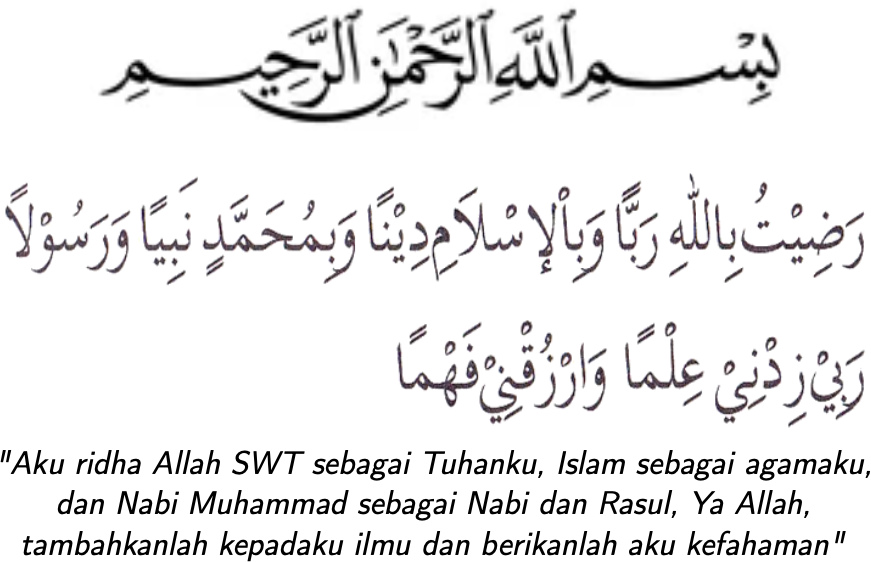

## Layer Cloud Computing

## Clients

Klien cloud (Cloud client) adalah perangkat keras dan/atau perangkat lunak yang bergantung pada komputasi cloud (cloud computing) untuk sebagian atau seluruh fungsionalitas mereka (seperti penyimpanan data, pemrosesan data, atau pengaturan aplikasi).

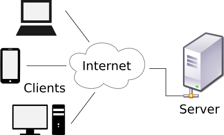

## Application

Sebuah aplikasi cloud (Cloud Application) mempengaruhi Cloud Computing (Komputerisasi cloud) pada arsitektur perangkat lunak (software), sering menghilangkan kebutuhan untuk menginstal dan menjalankan aplikasi pada pengguna (user) sendiri, dengan demikian mengurangi beban dari pemeliharaan perangkat lunak, operasi berkelanjutan, dan dukungan.

[figure not shown]

## Platform

Suatu platform cloud (cloud platform) mengantarkan sebuah platform komputasi dan/atau solusi tumpukan (solution stack) sebagai satu jasa, umumnya menggunakan infrastruktur cloud (cloud infrastructure) dan aplikasi pendukung cloud (supporting cloud applications). Hal ini memudahkan penyebaran aplikasi tanpa biaya dan kompleksitas dari pembelian dan mengatur perangkat keras dasar dan lapisan perangkat lunak.

## Infrastructure

Infrastruktur cloud (Cloud infrastructure) adalah pengiriman dari infrastruktur komputer, yang secara khusus pada suatu platform lingkungan virtualisasi, sebagai satu jasa.

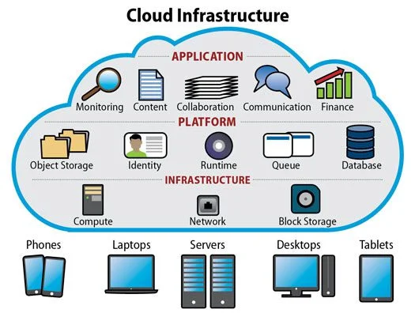

## Servers

Lapisan server terdiri dari perangkat keras komputer dan/atau produk perangkat lunak komputer yang terperinci didisain untuk pengiriman dari jasa cloud (cloud services). Untuk beberapa tahun Kedepannya teknologi Cloud Computing akan berkembang secara pesat seiring dengan kemajuan teknologi yang didukung oleh perusahaan besar seperti IBM, Google, Microsoft, Yahoo, Amazon, dan lain-lain sehingga proses pengiriman dan penerimaan data menjadi lebih baik sehingga setiap orang dapat menikmati layanan internet dengan Cepat dan Murah.

## Tipe Layanan Cloud Computing

## Public Cloud

Cloud Public atau cloud eksternal mendeskripsikan komputasi cloud pada arti tendensi tradisional, yang mana sumber daya dengan ketentuan dinamis pada suatu fine-grained (perbaikan), basis pelayanan sendiri lewat Internet, melalui aplikasi web / jasa web, dari satu lokasi penyedia off-site oleh pihak ketiga yang berbagi sumber daya dan daftar kegunaan pada suatu fine-grained utility computing.

## Community Cloud

Dalam model ini, sebuah infrastruktur cloud digunakan bersama-sama oleh beberapa organisasi yang memiliki kesamaan kepentingan, misalnya dari sisi misinya, atau tingkat keamanan yang dibutuhkan, dan lainnya. Jadi, community cloud ini merupakan “pengembangan terbatas” dari private cloud. Dan sama juga dengan private cloud, infrastruktur cloud yang ada bisa di-manage oleh salah satu dari organisasi itu, ataupun juga oleh pihak ketiga.

## Private Cloud

Private Cloud dan cloud internal adalah pembentukan kata baru yang yang baru-baru ini telah dipergunakan oleh beberapa penjual (vendor) untuk deskripsikan penawaran yang menandingi Cloud Computing (Komputerisasi cloud) pada jaringan pribadi. Produk ini (secara khas virtualisasi otomatisasi) menyatakan “mengantarkan beberapa keuntungan-keuntungan dari Cloud Computing (Komputerisasi cloud) tanpa jebakan (pitfalls)”, kapitalisasi pada jaminan sekuritas data, perusahaan pemerintahan, dan dapat diandalkan.

## Hybrid Cloud

Untuk jenis ini, infrastruktur cloud yang tersedia merupakan komposisi dari dua atau lebih infrastruktur cloud (private, community, atau public). Di mana meskipun secara entitas mereka tetap berdiri sendiri-sendiri, tapi dihubungkan oleh suatu teknologi/mekanisme yang memungkinkan portabilitas data dan aplikasi antar cloud itu Misalnya, mekanisme load balancing yang antar cloud, sehingga alokasi sumberdaya bisa dipertahankan pada level yang optimal.

## Penutup

[figure not shown]